# 데이터 과학 – 기초 통계

탐색적 요인분석(Exploratory Factor Analysis)

# 1 요인분석(factor analysis) [^1] [^2] [^3]

1904년에 찰스 스피어만(C.Spearman)에 의해 개발되었으며, 어떤 변인 (질문 문항, 측정 대상)들 간에 공통적인 요인이 있다고 가정하고, 그 변수들 간의 상호 관련성을 소수의 잠재 요인으로 집약하는 방법이다.

$$X = \Lambda f + \epsilon$$

## 1.1 요인분석 데이터 생성

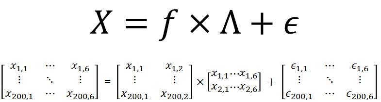

- `X_mat` : $N \times P$ 행렬($200 \times 6$)
- `lambda`: $\Lambda$, 요인적재(factor loading) $P \times Q$ 행렬($6 \times 2$)
- `FF`: 요인점수(Factor Score), $N \times Q$ 행렬($200 \times 2$) 행렬.
- `E`: 오차 행렬, $N \times P$ 행렬($200 \times 6$)

```r
# 0. 환경설정 -----
library(tidyverse)
library(psych)
library(GPArotation)
library(mvtnorm)

# 1. 요인분석 데이터 생성 -----

N <- 200
P <- 6
Q <- 2
lambda <- matrix(c(0.7,-0.4, 0.8,0, -0.2,0.9, -0.3,0.4, 0.3,0.7, -0.8,0.1),
                  nrow=P, ncol=Q, byrow=TRUE)

FF <- rmvnorm(N, mean = c(5, 15), sigma=diag(Q)) # 요인점수(factor score)
E  <- rmvnorm(N, mean = rep(0, P), sigma=diag(P))
X_mat  <- FF %*% t(lambda) + E
```

## 1.2 모의실험 요인분석

가장 먼저 요인 갯수를 선정한다. 이를 위해서 `scree()` 함수를 사용해서 팔꿈치가 꺾어지는 지점 요인 2개로 선정한다.

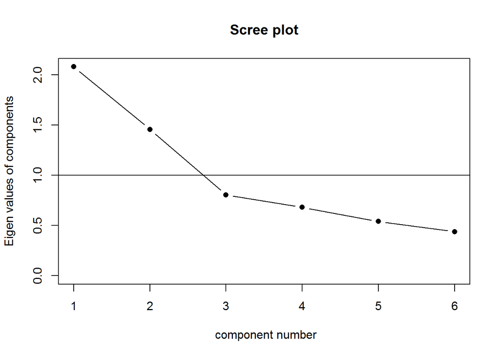

```r
# 2. 요인분석 -----
## 2.1. 요인수 결정 -----
X_cor <- cor(X_mat, use = "pairwise.complete.obs")

scree(X_cor, factors = FALSE)
```

`psych` 팩키지 `fa()` 함수를 사용해서 `nfactors=2`로 지정한 후에 요인분석 모형 적합을 시도한다. RMSEA, TLI 값을 통해 적합성을 확인한다.

```r
## 2.2. 요인분석 모형 적합 -----

X_fa <- fa(X_mat, nfactors=2, n.obs=N, rotate="varimax")

X_fa$RMSEA
```

```
     RMSEA      lower      upper confidence
0.06302048 0.00000000 0.13520388 0.90000000
```

```r
X_fa$TLI
```

```
[1] 0.9324473
```

`fa.plot()` 함수를 통해 6개 변수를 2개 요인으로 축약하는데 각 변수별 요인에 대한 기여분을 시각화한다.

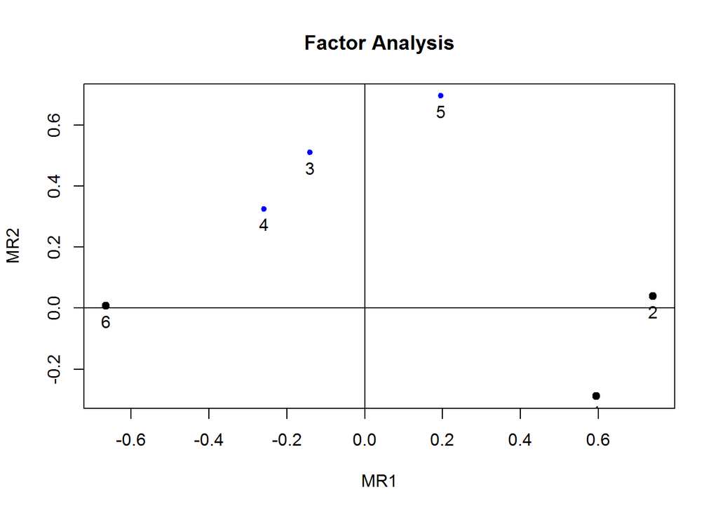

```r
## 2.3. 요인분석 모형 -----
fa.plot(X_fa)
```

```r
print(X_fa$loadings, cutoff = 0.2)
```

```
Loadings:
     MR1    MR2
[1,]  0.594 -0.289
[2,]  0.740
[3,]         0.510
[4,] -0.259  0.325
[5,]         0.695
[6,] -0.665

                 MR1   MR2
SS loadings    1.467 0.934
Proportion Var 0.245 0.156
Cumulative Var 0.245 0.400
```

커뮤니케이션을 위해서 측정변수와 요인(Factor)의 관계를 시각적으로 표현한다.

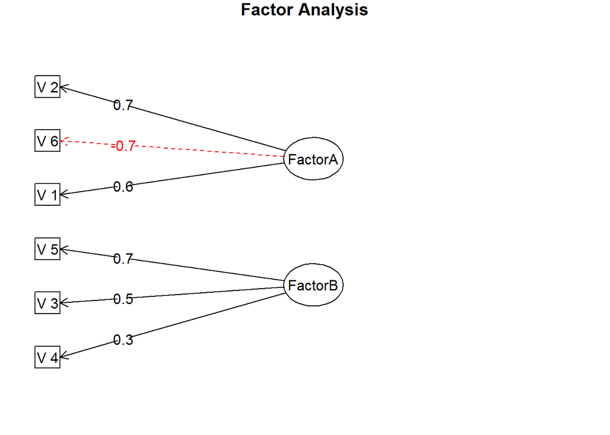

```r
colnames(X_fa$loadings) <- c("FactorA", "FactorB")

fa.diagram(X_fa)
```

# 2 요인분석 사례

[Exploratory Factor Analysis in R](https://www.promptcloud.com/blog/exploratory-factor-analysis-in-r/) 요인분석에 사용된 사례를 준용하여 자동차 구입에 중요한 요인을 추출해보자.

## 2.1 자동차 설문 데이터

탐색적 요인분석을 위한 데이터를 다운로드해서 살펴본다. EFA.csv 파일을 다운로드 받아 로컬 파일에 저장하는 것도 가능하고, 아니면 직접 `read_csv()` 함수로 데이터를 가져온다.

```r
# 0. 환경설정 -----
library(tidyverse)
library(psych)
library(GPArotation)

# 1. 데이터 -----
download.file(url="https://www.promptcloud.com/wp-content/uploads/2017/02/EFA.csv", destfile = "data/EFA.csv")

car_df <- read_csv("https://www.promptcloud.com/wp-content/uploads/2017/02/EFA.csv")
DT::datatable( options = list(scrollX = TRUE), car_df)
```

|  | Price | Safety | Exterior_Looks | Space_comfort | Technology | After_Sales_Service | Resale_Value | Fuel_Type | Fuel_Efficiency | Color | Maintenance | Test_drive | Product_reviews | Testimonials |
| --- | --- | --- | --- | --- | --- | --- | --- | --- | --- | --- | --- | --- | --- | --- |
| 1 | 4 | 4 | 5 | 4 | 3 | 4 | 5 | 4 | 4 | 2 | 4 | 2 | 4 | 3 |
| 2 | 3 | 5 | 3 | 3 | 4 | 4 | 3 | 4 | 3 | 4 | 3 | 2 | 2 | 2 |
| 3 | 4 | 4 | 3 | 4 | 5 | 5 | 5 | 4 | 5 | 4 | 5 | 4 | 4 | 3 |
| 4 | 4 | 4 | 4 | 3 | 3 | 4 | 5 | 5 | 4 | 4 | 4 | 2 | 5 | 3 |
| 5 | 5 | 5 | 4 | 4 | 5 | 4 | 5 | 3 | 4 | 5 | 5 | 5 | 5 | 2 |
| 6 | 4 | 4 | 5 | 3 | 4 | 5 | 3 | 4 | 3 | 2 | 3 | 2 | 2 | 3 |
| 7 | 3 | 4 | 3 | 4 | 3 | 5 | 3 | 4 | 5 | 4 | 3 | 5 | 2 | 4 |
| 8 | 4 | 3 | 4 | 4 | 5 | 4 | 5 | 4 | 4 | 4 | 5 | 2 | 4 | 4 |
| 9 | 5 | 4 | 5 | 4 | 3 | 5 | 5 | 4 | 4 | 4 | 4 | 2 | 4 | 4 |
| 10 | 4 | 4 | 3 | 3 | 5 | 4 | 5 | 5 | 4 | 5 | 5 | 2 | 2 | 4 |

[output cut: 80 more lines]

## 2.2 요인수 결정

요인분석에서 가장 답이 없지만 중요한 방식이 적정한 요인수를 결정하는 것이다. 원데이터에서 상관관계 행렬을 추출한 후에 `scree()` 함수로 요인수를 결정하거나, `fa.parallel()` 함수를 활용해서 적절한 요인수를 결정한다. 시각적으로 2~5개 요인이 적절해 보인다.

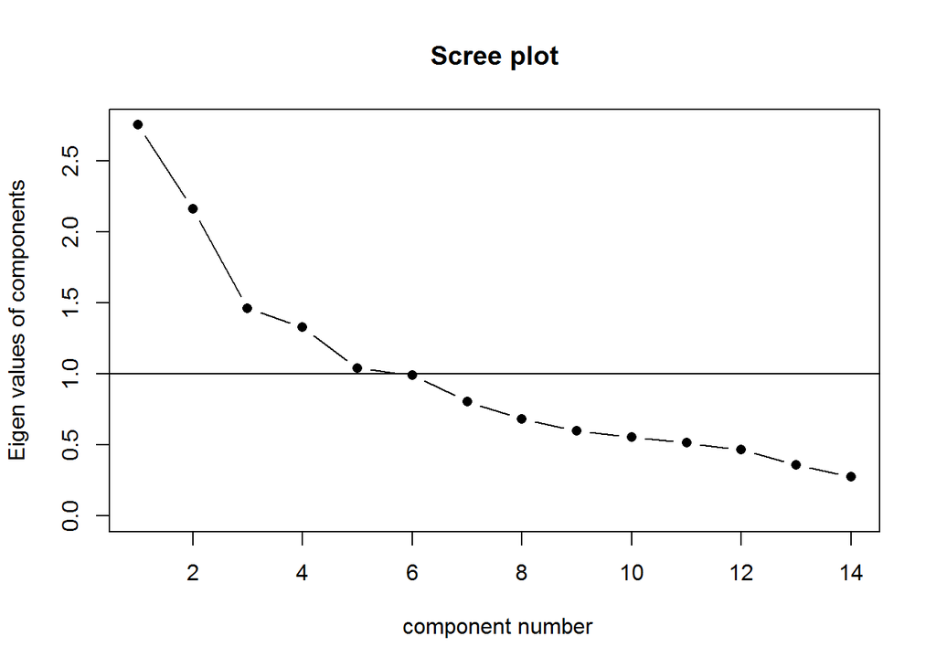

```r
# 2. 요인분석 -----
## 2.1. 요인수 결정 -----
### 2.1.1. 탐색적 요인수 결정 -----
car_cor <- cor(car_df, use = "pairwise.complete.obs")
scree(car_cor, factors = FALSE)
```

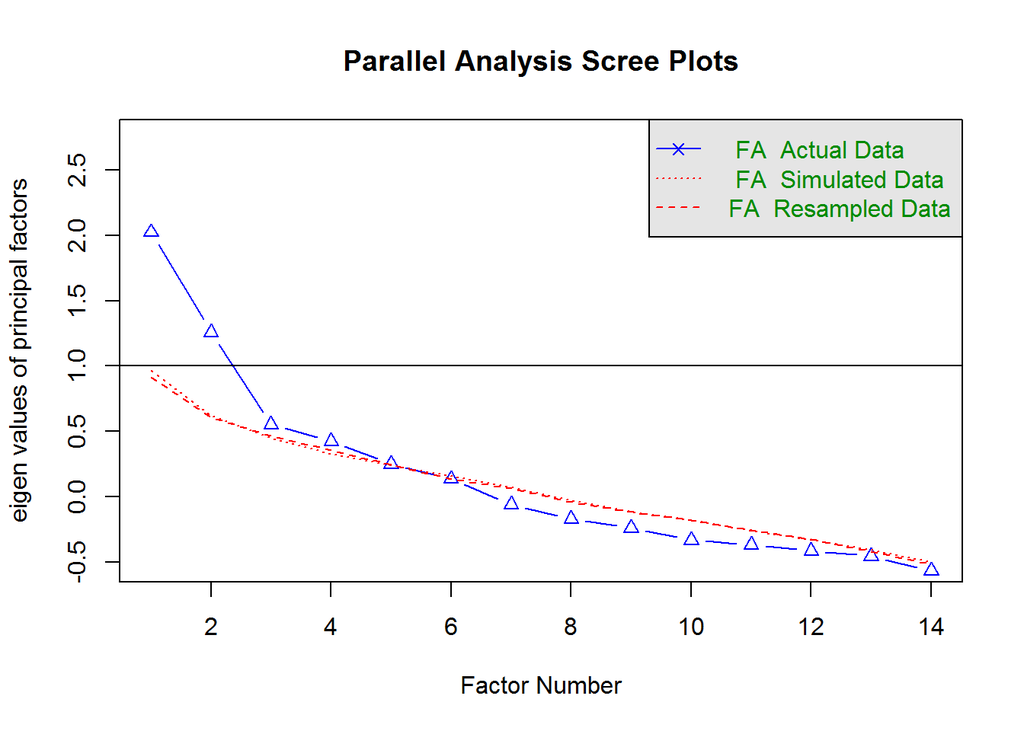

```
Parallel analysis suggests that the number of factors =  5  and the number of components =  NA
```

```r
car_parallel <- fa.parallel(car_df, fm = 'minres', fa = 'fa')
```

```r
### 2.1.2. 요인 수 결정 -----
car_two_fa   <- fa(car_df, nfactors=2, n.obs=N, rotate="varimax")
car_three_fa <- fa(car_df, nfactors=3, n.obs=N, rotate="varimax")
car_four_fa  <- fa(car_df, nfactors=4, n.obs=N, rotate="varimax")
car_five_fa  <- fa(car_df, nfactors=5, n.obs=N, rotate="varimax")

anova(car_two_fa, car_three_fa)
```

```
ANOVA Test for Difference Between Models

             Model Df ML Chisq Delta Df Delta Chisq Pr(> Delta Chisq)
car_two_fa         64   95.273
car_three_fa       52   68.463       12       26.81         0.0082298
             Emp Chisq  Delta Emp Chisq Pr(> Emp.Delta Chisq)     BIC
car_two_fa      117.75                                        -192.72
car_three_fa     71.69           46.061            6.7716e-06 -165.53
             Delta BIC
car_two_fa
car_three_fa    27.188
```

```r
anova(car_three_fa, car_four_fa)
```

```
ANOVA Test for Difference Between Models

             Model Df ML Chisq Delta Df Delta Chisq Pr(> Delta Chisq)
car_three_fa       52   68.463
car_four_fa        41   46.201       11      22.262          0.022419
             Emp Chisq  Delta Emp Chisq Pr(> Emp.Delta Chisq)     BIC
car_three_fa    71.690                                        -165.53
car_four_fa     38.461           33.229            0.00048305 -138.29
             Delta BIC
car_three_fa
car_four_fa     27.236
```

```r
anova(car_four_fa, car_five_fa)
```

```
ANOVA Test for Difference Between Models

            Model Df ML Chisq Delta Df Delta Chisq Pr(> Delta Chisq)
car_four_fa       41   46.201
car_five_fa       31   27.439       10      18.762          0.043393
            Emp Chisq  Delta Emp Chisq Pr(> Emp.Delta Chisq)     BIC
car_four_fa    38.461                                        -138.29
car_five_fa    20.204           18.257              0.050777 -112.06
            Delta BIC
car_four_fa
car_five_fa    26.236
```

## 2.3 요인분석 적합

요인 4개를 선정한 모형을 최종모형으로 하고 `RMSEA`, `TLI` 지표를 바탕으로 탐색적 요인분석 모형의 적합성을 확인한다.

```r
## 2.2. 요인모형 적합 -----
car_fa <- fa(car_df, nfactors = 4, rotate = "oblimin", fm="minres")

car_fa$RMSEA
```

```
     RMSEA      lower      upper confidence
0.05200437 0.00000000 0.08459318 0.90000000
```

```r
car_fa$TLI
```

```
[1] 0.9224231
```

## 2.4 요인분석 커뮤니케이션

선정된 요인 4개를 설문조사 문항과 결합하여 4개 요인에 대한 요인 명칭부여 작업을 수행한다.

- 외관: “Exterior_Looks”, “Color”
- 기능: “Space_comfort”, “Technology”, “Safety”, “After_Sales_Service”, “Fuel_Type”
- 가성비: “Price”, “Maintenance”, “Resale_Value”, “Fuel_Efficiency”
- 신뢰성: “Product_reviews”, “Testimonials”, “Test_drive”

```r
## 2.3. 요인모형 시각화 -----
colnames(car_fa$loadings) <- c("Factor_1", "Factor_2", "Factor_3", "Factor_4")
print(car_fa$loadings, cutoff = 0.3)
```

```
Loadings:
                    Factor_1 Factor_2 Factor_3 Factor_4
Price                0.544
Safety              -0.331    0.358
Exterior_Looks                        -0.548
Space_comfort                 0.782
Technology                    0.358
After_Sales_Service           0.537
Resale_Value         0.729
Fuel_Type                     0.575
Fuel_Efficiency      0.434             0.308
Color                                  0.731
Maintenance          0.562
Test_drive                                      0.365
Product_reviews      0.345                      0.364
Testimonials                                    0.685

               Factor_1 Factor_2 Factor_3 Factor_4
SS loadings       1.639    1.637    1.053    0.968
Proportion Var    0.117    0.117    0.075    0.069
Cumulative Var    0.117    0.234    0.309    0.378
```

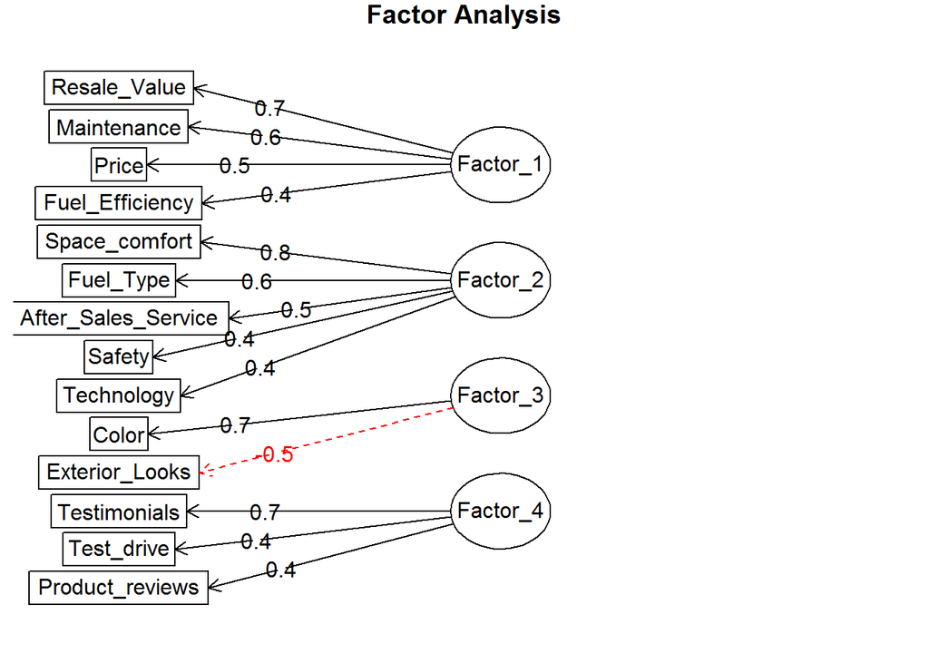

```r
fa.diagram(car_fa)
```

[^1]: [David A. Kenny (November 24, 2015), “Measuring Model Fit”](http://davidakenny.net/cm/fit.htm)
[^2]: [요인분석 - 나무위키](https://namu.wiki/w/%EC%9A%94%EC%9D%B8%20%EB%B6%84%EC%84%9D)
[^3]: [StackExchange - Looking for a step through an example of a factor analysis on dichotomous data (binary variables) using R](https://stats.stackexchange.com/questions/31948/looking-for-a-step-through-an-example-of-a-factor-analysis-on-dichotomous-data)